# Spectra reconstruction analysis

Ellie Dunstone

2023-02-17

```r
library(tidyverse)
library(patchwork)
library(sigfit)
library(ggrepel)
```

## Introduction

This is a script for analysing and exploring the quality of the spectrum reconstructions generated during signature extraction or fitting using sigfit, which can be installed from https://github.com/kgori/sigfit. Reconstructions of your samples under the ‘model’ you have calculated can be produced for all three modalities implemented in sigfit: reference signature fitting; de novo signature extraction; and combined fitting and extraction (FitExt). For further explanation, see the vignettes on the sigfit github, or my own ‘sigfit_signature_analysis.Rmd’ script that implements the sigfit package (not yet on GitHub, contact me if you want it).

Sigfit allows us to examine how effectively the estimated signatures and/or exposures can reconstruct the original mutational catalogues by producing spectrum reconstruction plots with the ‘plot_reconstruction’ function. The underlying data can be accessed using the ‘get_reconstructions’ function, which provides the input data for this script. Some of the content of this script is adapted from the ‘plot_reconstruction’ function written by the authors of sigfit.

## Read in data

First, we read in the reconstruction data. You should read in the .rds object output by get_reconstructions, and can also read this data in as the three individual tables that this object is comprised of. Depending on exactly what you do downstream you might not need all of these - choose your own adventure.

```r
#read reconstructions table
recons <- as.matrix(read.csv("/Users/ed4/Documents/phd/chemo_project/BotSeq/panbody/panbody_20230106/extractions/20230217_panbody_2745_SF_COSMIC_fit_SBS96_reconstruction_analysis_test/ref_fit_hpd_0.01_reconstructions.csv"))[,-1]

#read reconstructions hpd table
recon_hpds <- as.data.frame(read.csv("/Users/ed4/Documents/phd/chemo_project/BotSeq/panbody/panbody_20230106/extractions/20230217_panbody_2745_SF_COSMIC_fit_SBS96_reconstruction_analysis_test/ref_fit_hpd_0.01_reconstructions_hpds.csv"))[,-1]

#read reconstructions exposures table
recon_exposures <- as.data.frame(read.csv("/Users/ed4/Documents/phd/chemo_project/BotSeq/panbody/panbody_20230106/extractions/20230217_panbody_2745_SF_COSMIC_fit_SBS96_reconstruction_analysis_test/ref_fit_hpd_0.01_reconstructions_exposures.csv"))[,-1]

#read in whole object as rds
recons_all_obj <- readRDS("/Users/ed4/Documents/phd/chemo_project/BotSeq/panbody/panbody_20230106/extractions/20230217_panbody_2745_SF_COSMIC_fit_SBS96_reconstruction_analysis_test/ref_fit_hpd_0.01_reconstructions.rds")
```

We also need the original mutation catalogue used to generate the solution - this describes the sample spectra that we are trying to reconstruct using our model. This should be in the format used by sigfit (i.e. a numeric matrix with one row per sample and one column per mutation type).

```r
#read in catalogue in sigfit format
mutation_catalogue <- as.matrix(read.csv("/Users/ed4/Documents/phd/chemo_project/BotSeq/panbody/panbody_20230106/data/sigfit_mutation_catalogue.csv", row.names = 1))
colnames(mutation_catalogue) <- str_replace(colnames(mutation_catalogue), "\\.", ">") #Note: this line is only needed because exporting and reimporting the catalogue causes the "<" in the mutation types to be replaced with "." and I want to switch this back

#assign number of mut categories and samples
ncat <- ncol(mutation_catalogue)   # number of categories
nsamp <- nrow(mutation_catalogue)  # number of samples
```

## Calculating cosine similarities

We now want to assess the quality of the reconstruction for each sample. This is done by calculating the cosine similarity between the observed mutation spectrum, and the reconstructed spectrum generated under our model.

```r
#extract array from rds reconstructions object - 3 dimensions not easy to read back in due to flattening during export/import as individual item (though this may be possible? idk)
reconstructions <- recons_all_obj$reconstructions

#NB//// need to make sure am matching correct samples definitely -  can check results

#get mutation counts from catalogue
counts <- mutation_catalogue

#init cosine sim dataframe
cossim_table <- as.data.frame(matrix(data = NA, nrow = nsamp, ncol = 3))
colnames(cossim_table) <- c("sample", "recon_cossim", "total_mut_count")

#calculate cosine sims and total mutation counts, and populate table
for (i in 1:nsamp) {
  cossim_table$sample[i] <- rownames(counts)[i]
  cossim_table$recon_cossim[i] <- cosine_sim(counts[i,], colSums(reconstructions[i, , ]))
  cossim_table$total_mut_count[i] <- rowSums(counts)[i]
}

#output table
write.csv(cossim_table, "/Users/ed4/Documents/phd/chemo_project/BotSeq/panbody/panbody_20230106/extractions/20230217_panbody_2745_SF_COSMIC_fit_SBS96_reconstruction_analysis_test/reconstruction_cossim_table.csv")
```

## Plotting reconstruction cosine similarity distribution

We can now plot the distribution of the reconstruction cosine similarities to assess the fit of the model at a per-sample level.

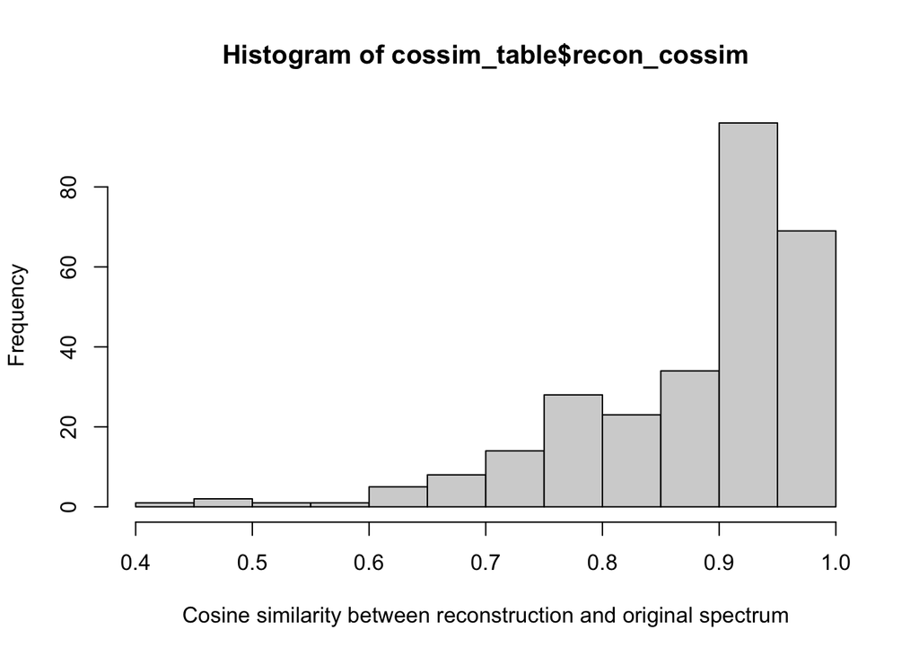

```r
#Plot recon cossims as histogram
cossim_hist <- hist(cossim_table$recon_cossim, xlab = "Cosine similarity between reconstruction and original spectrum")
```

```r
cossim_hist
```

```
## $breaks
##  [1] 0.40 0.45 0.50 0.55 0.60 0.65 0.70 0.75 0.80 0.85 0.90 0.95 1.00
##
## $counts
##  [1]  1  2  1  1  5  8 14 28 23 34 96 69
##
## $density
##  [1] 0.07092199 0.14184397 0.07092199 0.07092199 0.35460993 0.56737589
##  [7] 0.99290780 1.98581560 1.63120567 2.41134752 6.80851064 4.89361702
##
## $mids
##  [1] 0.425 0.475 0.525 0.575 0.625 0.675 0.725 0.775 0.825 0.875 0.925 0.975
##
## $xname
## [1] "cossim_table$recon_cossim"
##
## $equidist
## [1] TRUE
##
## attr(,"class")
## [1] "histogram"
```

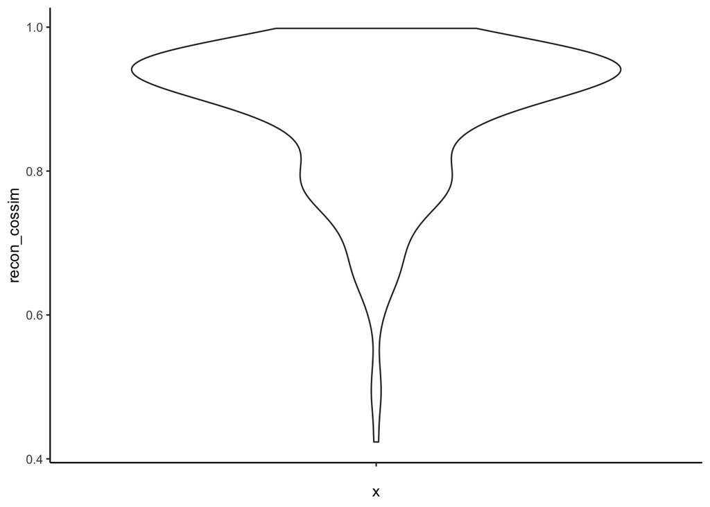

```r
#Plot recon cossims as violin plot
cossim_violin <- ggplot(cossim_table, aes(x = "", y = recon_cossim)) +
  geom_violin() +
  theme_classic()

cossim_violin
```

We can also plot the reconstruction cosine similarity according to the total raw mutation number in each sample. This is useful, as one explanation for poor reconstruction quality for a particular sample is low raw mutation number.

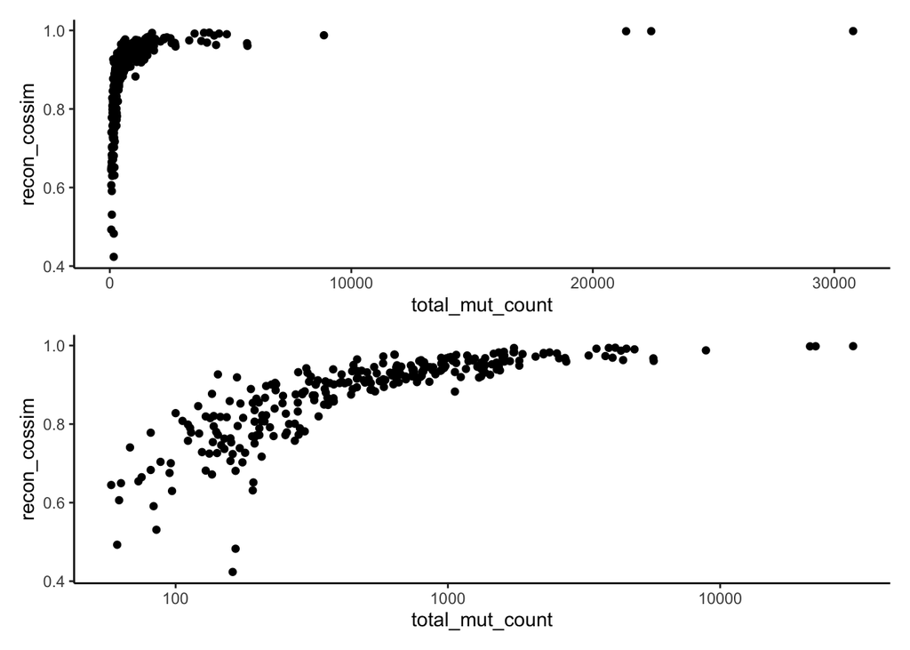

```r
#create scatterplot of reconstruction cossim vs. total mut count for each sample
cossim_v_mut_count_plot <- ggplot(cossim_table, aes(total_mut_count, recon_cossim)) +
  geom_point() +
  theme_classic()

#create same plot with log10 x axis - useful if you have a big range of total muts
cossim_v_mut_count_plot_log <- cossim_v_mut_count_plot + scale_x_log10()

#display plots
cossim_v_mut_count_plot / cossim_v_mut_count_plot_log
```

We can also attempt to linearise this relationship by transforming the data. Here I have used the reciprocal of mutation count, but this may not work for other datasets and please check your own work if you start trying to fit a linear model.

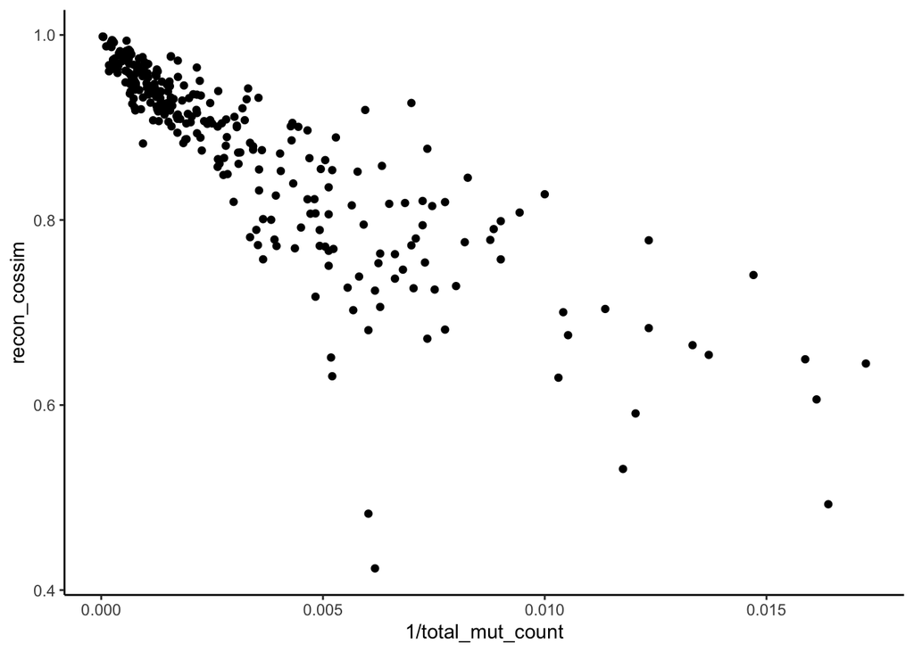

```r
#attempt to linearise by plotting against 1/total_mut_count
cossim_v_mut_count_plot_transform <- ggplot(cossim_table, aes(1/total_mut_count, recon_cossim)) +
  geom_point() +
  theme_classic()

cossim_v_mut_count_plot_transform
```

## Visual identification of outliers

I’ll go back and probably do something about the above (potentially involving regression?) at some point, but for now realistically I just want to label the points so I can visually identify which samples are the obvious outliers.

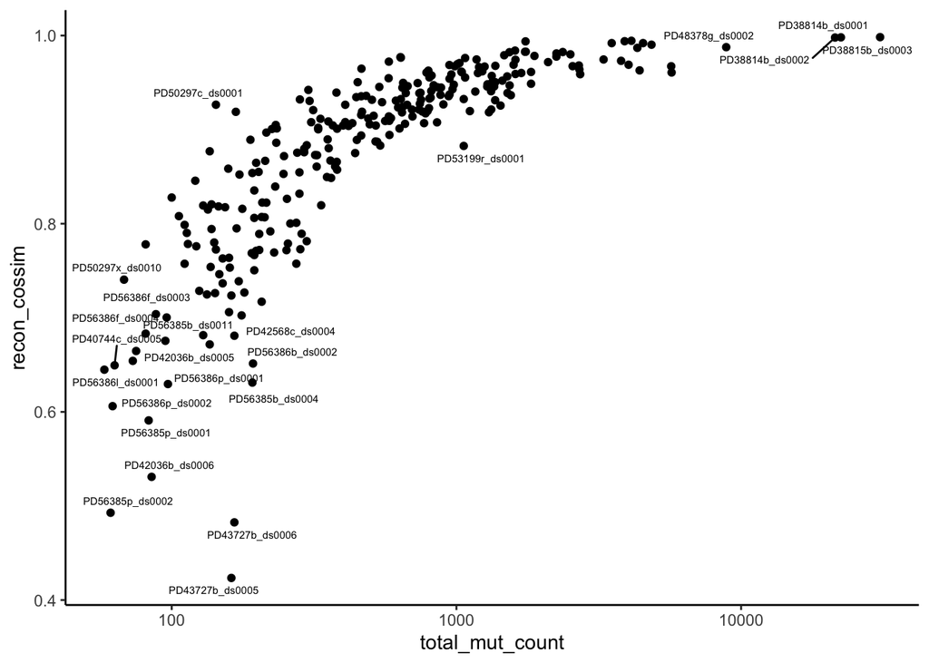

```r
#replot the plot from above with added labels to visually ID outliers
cossim_v_mut_count_plot_log +
  geom_text_repel(aes(label=sample), size=2)
```

We can now see the names of the samples with lower reconstruction cosine similarity than other samples in the dataset with the same number of total mutations. This can help to identify samples where the current model may be lacking, and an unaccounted-for mutational process may be present. You can either go and look at these reconstructions yourself if you have the whole lot plotted already, or use the code below to take a look at the reconstructions for specific samples you are interested in.

## Inspect poorly-reconstructed samples

We can now look at any samples that show poor reconstruction given their mutation number.

First, we want to input a list of the sample names we are interested in. At some point this could also be adapted to optionally ID the outliers from the plot above automatically, but at the moment it needs manual input.

```r
sample_list_inspect <- c("PD43727b_ds0005", "PD43727b_ds0006", "PD56386b_ds0002", "PD56385b_ds0004")
```

In order to plot the reconstructions, we also need the signatures used in this solution:

```r
signatures <- read.csv2("/Users/ed4/Documents/phd/chemo_project/BotSeq/panbody/panbody_20230106/extractions/20230217_panbody_2745_SF_COSMIC_fit_SBS96_reconstruction_analysis_test/ref_fit_hpd_0.01_signatures.csv", sep = ",", row.names = 1)
signatures[] <- lapply(signatures, as.numeric)
```

We can now plot the reconstructions for these samples:

```
## [1] "Plotting reconstruction for sample PD43727b_ds0005..."
## Building reconstructed catalogues...
## Plotting reconstructed catalogues...
```

```
## Building reconstructed catalogues...
## Plotting reconstructed catalogues...
```

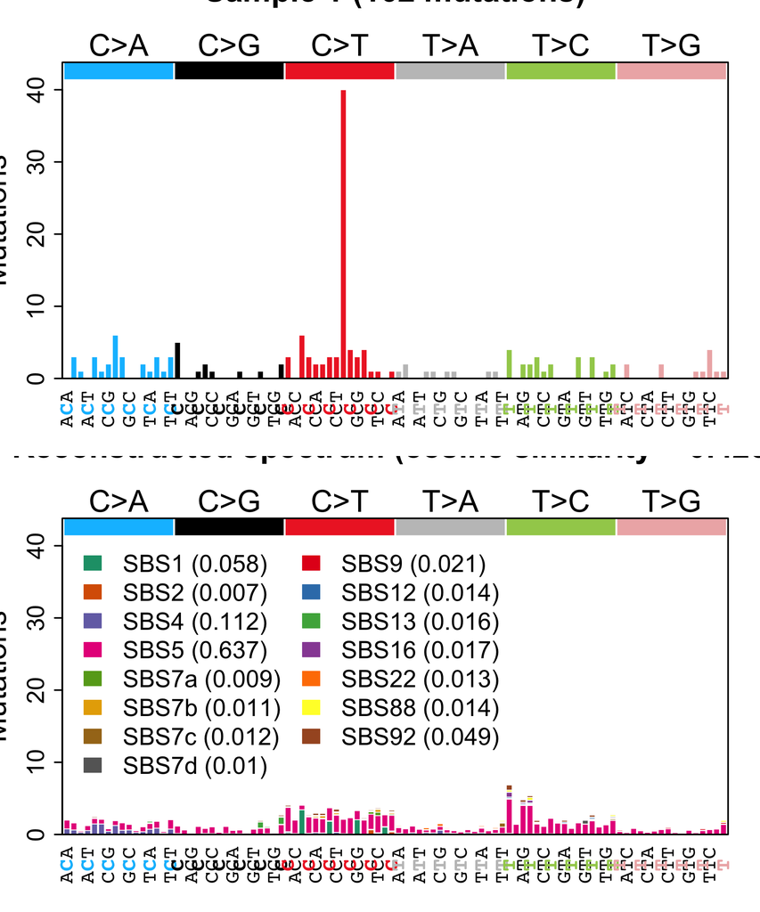

```
## [1] "Plotting reconstruction for sample PD43727b_ds0006..."
## Building reconstructed catalogues...
## Plotting reconstructed catalogues...
```

```
## Building reconstructed catalogues...
## Plotting reconstructed catalogues...
```

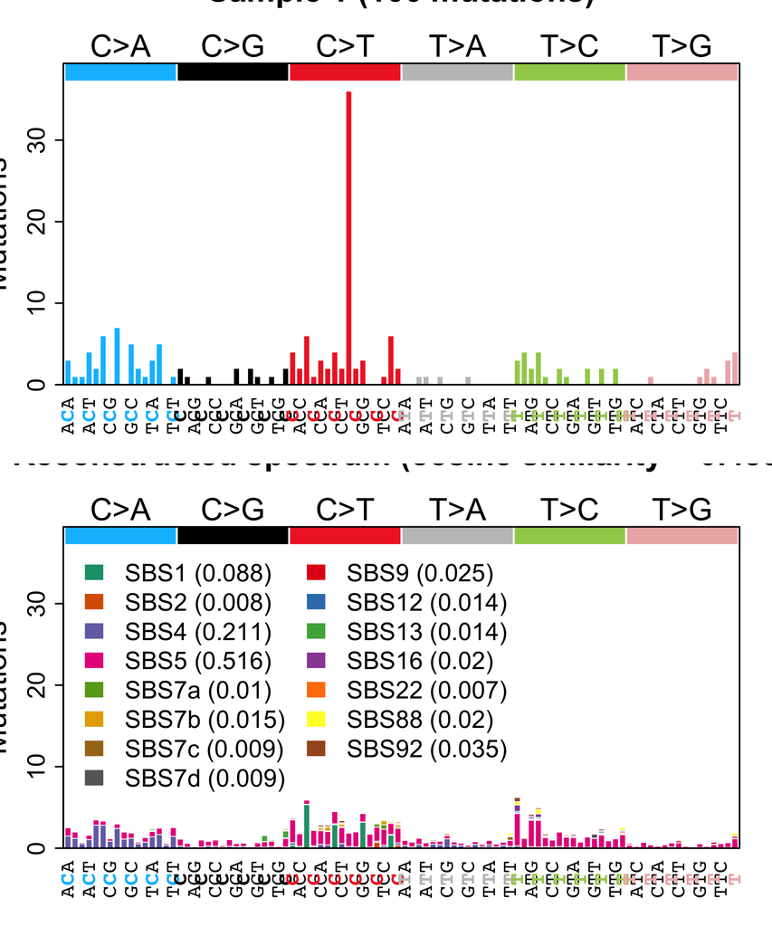

```
## [1] "Plotting reconstruction for sample PD56386b_ds0002..."
## Building reconstructed catalogues...
## Plotting reconstructed catalogues...
```

```
## Building reconstructed catalogues...
## Plotting reconstructed catalogues...
```

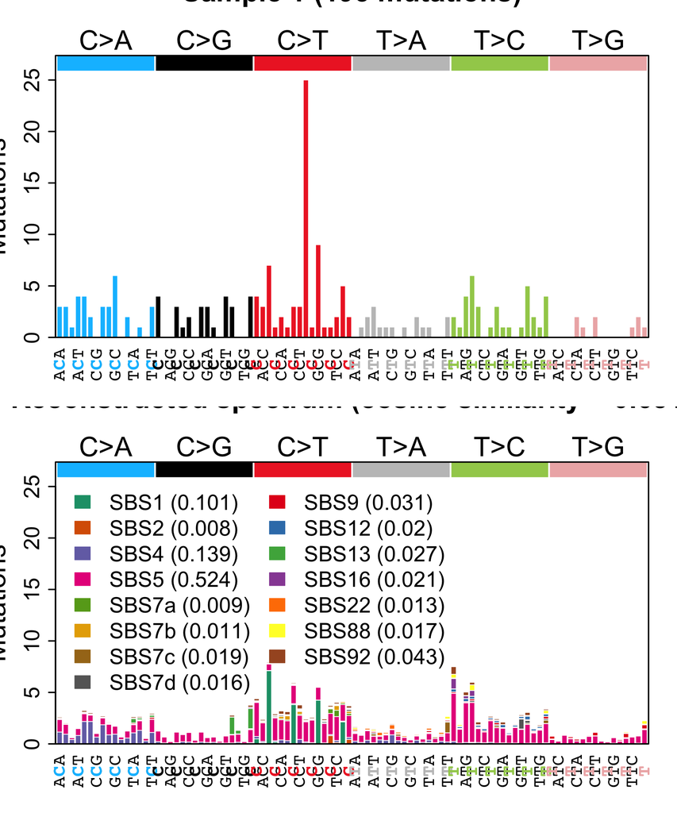

```
## [1] "Plotting reconstruction for sample PD56385b_ds0004..."
## Building reconstructed catalogues...
## Plotting reconstructed catalogues...
```

```
## Building reconstructed catalogues...
## Plotting reconstructed catalogues...
```

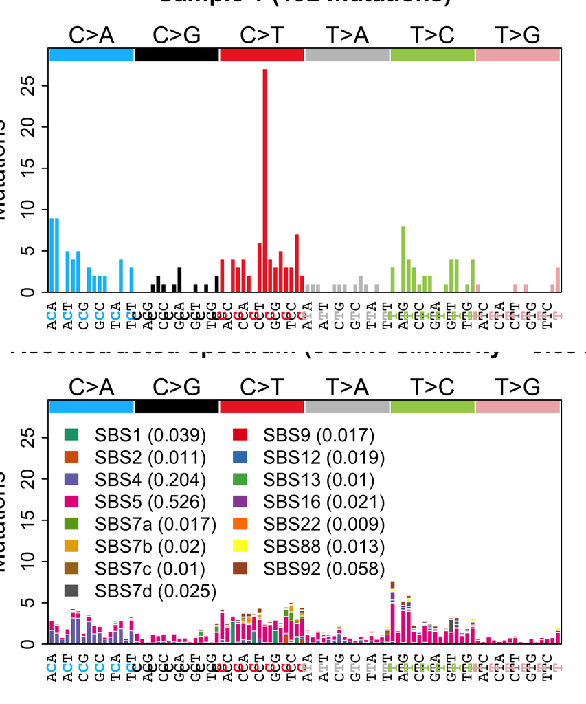

```r
#plot the reconstruction inline and to file for each sample in your list to query
for (i in sample_list_inspect) {
  print(paste0("Plotting reconstruction for sample ", i, "..."))
  n <- which(rownames(counts) == i)
  counts_n <- counts[n,]
  exposures_n <- recon_exposures[n,]
  plot_reconstruction(counts = counts_n, signatures = signatures, exposures = exposures_n, legend_cex = 0.1) # plot inline, not displaying nicely currently
  plot_reconstruction(counts = counts_n, signatures = signatures, exposures = exposures_n, pdf_path = paste0("/Users/ed4/Documents/phd/chemo_project/BotSeq/panbody/panbody_20230106/extractions/20230217_panbody_2745_SF_COSMIC_fit_SBS96_reconstruction_analysis_test/", i, "_reconstruction_plot.pdf")) # output to pdf to view properly
}
```

You can inspect these plots to attempt to identify why the reconstruction may be poor here. In this case, there is clearly an individual peak that is unaccounted for in this fitting of COSMIC signatures, which suggests that a method incorporating de novo extraction may be beneficial for this dataset.